# Jeu de données: LAozone

PRAMA

[figure not shown]

# Packages

Références des bibliothèques

- [scikit-learn](https://scikit-learn.org/)
  - [Linear models](https://scikit-learn.org/stable/modules/linear_model.html)
  - [CART](https://scikit-learn.org/stable/modules/tree.html)
  - [Random forest](https://scikit-learn.org/stable/modules/ensemble.html#forests-of-randomized-trees)
  - [Gradient boosting](https://scikit-learn.org/stable/modules/ensemble.html#gradient-tree-boosting)
- [pygam](https://pygam.readthedocs.io/en/latest/)
- [statsmodels](https://www.statsmodels.org/stable/nonparametric.html?highlight=kernel#)
- [pandas](https://pandas.pydata.org/docs/getting_started/index.html)
- [matplotlib](https://matplotlib.org/)
- [numpy](https://numpy.org)

Pour les régression linéaires avec ou sans pénalisation (Classique, Ridge, LASSO/LARS, ElasticNet)

```python
from sklearn import linear_model
```

Pour les kernel regression

```python
from statsmodels.nonparametric import kernel_regression
```

Pour les GAM

```python
import pygam
```

Pour les CART (Classification And Regression Tree)

```python
from sklearn import tree
```

Pour les random forest et gradient boosting

```python
from sklearn import ensemble
```

Pour charger les datasets et visualiser les données

```python
import pandas as pd
from matplotlib import pyplot as plt
```

Utilitaire de calcul scientifique

```python
import numpy as np
```

# Importation des données

Assurez-vous d'avoir le fichier "LAozone.csv" dans le même dossier que le script/notebook python.

```python
ozonedf = pd.read_csv("LAozone.csv") # Chargement des données ozone dans un objet pandas 'DataFrame' ozonedf
ozonedf
```

|  | ozone | vh | wind | humidity | temp | ibh | dpg | ibt | vis | doy |
| --- | --- | --- | --- | --- | --- | --- | --- | --- | --- | --- |
| 0 | 3 | 5710 | 4 | 28 | 40 | 2693 | -25 | 87 | 250 | 3 |
| 1 | 5 | 5700 | 3 | 37 | 45 | 590 | -24 | 128 | 100 | 4 |
| 2 | 5 | 5760 | 3 | 51 | 54 | 1450 | 25 | 139 | 60 | 5 |
| 3 | 6 | 5720 | 4 | 69 | 35 | 1568 | 15 | 121 | 60 | 6 |
| 4 | 4 | 5790 | 6 | 19 | 45 | 2631 | -33 | 123 | 100 | 7 |
| ... | ... | ... | ... | ... | ... | ... | ... | ... | ... | ... |
| 325 | 8 | 5630 | 4 | 50 | 50 | 2851 | -5 | 100 | 70 | 359 |
| 326 | 2 | 5730 | 3 | 53 | 51 | 111 | -14 | 225 | 200 | 362 |
| 327 | 3 | 5690 | 3 | 23 | 51 | 5000 | -36 | 107 | 70 | 363 |
| 328 | 5 | 5650 | 3 | 61 | 50 | 3704 | 18 | 83 | 40 | 364 |
| 329 | 1 | 5550 | 4 | 85 | 39 | 5000 | 8 | 44 | 100 | 365 |

330 rows × 10 columns

# Création d'un échantillon apprentissage et test

```python
from sklearn.model_selection import train_test_split
X = ozonedf.drop(['ozone'],axis=1)
Y = ozonedf['ozone']
Xtrain,Xtest,Ytrain,Ytest = train_test_split(X,Y,train_size=0.75,random_state=111)
```

# Définition des risques empiriques

```python
from sklearn.metrics import mean_squared_error
# Definition of the root mean squared error
def rmse(y,yprime):
    return np.sqrt(mean_squared_error(y,yprime))
# Definition of the mean absolute percentage error
def mape(y,yprime):
    return 100 * np.sum(np.abs(y-yprime)/y)/len(y)
mape_error_synt = {}
rmse_error_synt = {}
```

# 1. Statistiques descriptives

```python
from pandas.plotting import scatter_matrix
ozonedf.describe()
```

|  | ozone | vh | wind | humidity | temp | ibh | dpg | ibt | vis | doy |
| --- | --- | --- | --- | --- | --- | --- | --- | --- | --- | --- |
| count | 330.000000 | 330.000000 | 330.000000 | 330.000000 | 330.000000 | 330.000000 | 330.000000 | 330.000000 | 330.000000 | 330.000000 |
| mean | 11.775758 | 5750.484848 | 4.890909 | 58.130303 | 61.754545 | 2572.875758 | 17.369697 | 161.160606 | 124.533333 | 181.727273 |
| std | 8.011277 | 105.708241 | 2.293159 | 19.865000 | 14.458737 | 1803.885870 | 35.717181 | 76.679424 | 79.362393 | 106.060593 |
| min | 1.000000 | 5320.000000 | 0.000000 | 19.000000 | 25.000000 | 111.000000 | -69.000000 | -25.000000 | 0.000000 | 3.000000 |
| 25% | 5.000000 | 5690.000000 | 3.000000 | 47.000000 | 51.000000 | 877.500000 | -9.000000 | 107.000000 | 70.000000 | 90.250000 |
| 50% | 10.000000 | 5760.000000 | 5.000000 | 64.000000 | 62.000000 | 2112.500000 | 24.000000 | 167.500000 | 120.000000 | 177.500000 |
| 75% | 17.000000 | 5830.000000 | 6.000000 | 73.000000 | 72.000000 | 5000.000000 | 44.750000 | 214.000000 | 150.000000 | 275.750000 |
| max | 38.000000 | 5950.000000 | 21.000000 | 93.000000 | 93.000000 | 5000.000000 | 107.000000 | 332.000000 | 350.000000 | 365.000000 |

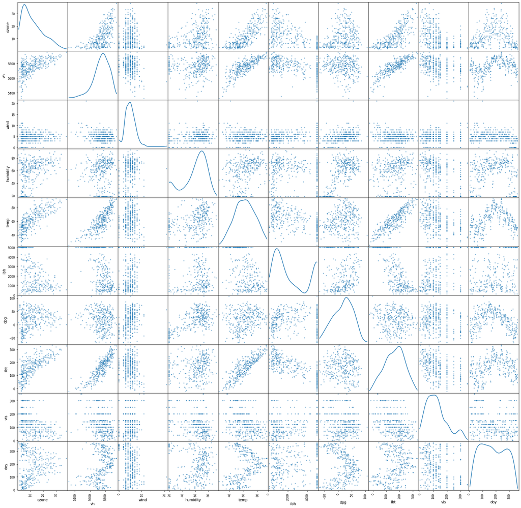

```python
import warnings
warnings.filterwarnings('ignore')
scatter_matrix(ozonedf, diagonal="kde",figsize=(25,25))
pass
```

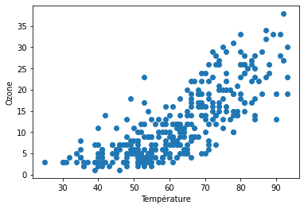

```python
plt.scatter(ozonedf['temp'],ozonedf['ozone'])
plt.xlabel('Température')
plt.ylabel('Ozone')
```

# 2.1 Régression linéaire

```python
reglin21 = linear_model.LinearRegression()
reglin21.fit(Xtrain[['temp']],Ytrain)
Y_prediction21 = reglin21.predict(Xtest[['temp']])
print("Coefficients: ",reglin21.coef_,"\nIntercept:",reglin21.intercept_,"\nCoefficent of determination",reglin21.score(Xtrain[['temp']],Ytrain))
```

```
Coefficients:  [0.43664357]
Intercept: -15.028261653889171
Coefficent of determination 0.6222718223366094
```

```python
# The empirical risks are defined just before section 1
mape_error_synt['Simple linear regression'] = mape(Y_prediction21,Ytest)
rmse_error_synt['Simple linear regression'] = rmse(Y_prediction21,Ytest)
print("RMSE={} \nMAPE={}".format(rmse(Y_prediction21,Ytest),mape(Y_prediction21,Ytest)))
```

```
RMSE=5.038801042245063
MAPE=54.68578632634199
```

# 2.2 Régression polynomiale

```python
from sklearn.preprocessing import PolynomialFeatures
poly = PolynomialFeatures(2,include_bias=False)
Xtrain_temp22 =  poly.fit_transform(Xtrain[['temp']])
Xtrain_temp22[1:10]
```

```
array([[  47., 2209.],
       [  67., 4489.],
       [  40., 1600.],
       [  55., 3025.],
       [  80., 6400.],
       [  93., 8649.],
       [  65., 4225.],
       [  66., 4356.],
       [  48., 2304.]])
```

```python
reglin22 = linear_model.LinearRegression()
reglin22.fit(Xtrain_temp22,Ytrain)
print("Coefficients: ",reglin22.coef_,"\nIntercept:",reglin22.intercept_,"\nCoefficent of determination",reglin22.score(Xtrain_temp22,Ytrain))
```

```
Coefficients:  [-0.5195829   0.00786102]
Intercept: 12.358824217490476
Coefficent of determination 0.6811284406648268
```

```python
Xtest_temp22 =  poly.fit_transform(Xtest[['temp']])
Y_prediction22 = reglin22.predict(Xtest_temp22)
# The empirical risks are defined just before section 1
mape_error_synt['Polynomial regression'] = mape(Y_prediction22,Ytest)
rmse_error_synt['Polynomial regression'] = rmse(Y_prediction22,Ytest)
print("RMSE={} \nMAPE={}".format(rmse(Y_prediction22,Ytest),mape(Y_prediction22,Ytest)))
```

```
RMSE=5.249942537350876
MAPE=37.851701438041665
```

# 2.3 Régression linéaire multiple

```python
reglin23 = linear_model.LinearRegression()
reglin23.fit(Xtrain,Ytrain)
Y_prediction23 = reglin23.predict(Xtest)
print("Coefficients: ",reglin23.coef_,"\nIntercept:",reglin23.intercept_,"\nCoefficent of determination:",reglin23.score(Xtrain,Ytrain))
```

```
Coefficients:  [-0.00559472  0.01814233  0.09300589  0.3115184  -0.00034548 -0.01655386
  0.02234449 -0.00704898 -0.01037595]
Intercept: 19.83295140827687
Coefficent of determination: 0.7184473574241609
```

```python
# The empirical risks are defined just before section 1
mape_error_synt['Multiple linear regression'] = mape(Y_prediction23,Ytest)
rmse_error_synt['Multiple linear regression'] = rmse(Y_prediction23,Ytest)
print("RMSE={} \nMAPE={}".format(rmse(Y_prediction23,Ytest),mape(Y_prediction23,Ytest)))
```

```
RMSE=4.645442909229788
MAPE=58.57548623214629
```

# 3. Régression ridge

Ici, la classe `RidgeCV` nous permet directement de choisir le paramètre $\alpha$ par cross validation (via un estimateur leave-one-out). Il faut donner les paramètres à tester via le paramètres `alphas`.

On définir notre propre modèle ridge en instantiant une classe `Ridge(`$\alpha$`)`

```python
from sklearn.linear_model import RidgeCV,Ridge
# Choix du paramètre alpha par cross-validation
cross_validation_ridge = RidgeCV(alphas = np.arange(10,4000,1)+0.1)
cross_validation_ridge.fit(Xtrain,Ytrain)
best_alpha = cross_validation_ridge.alpha_
ridge_model = Ridge(best_alpha)
ridge_model.fit(Xtrain,Ytrain)
```

```
Ridge(alpha=854.1, copy_X=True, fit_intercept=True, max_iter=None,
      normalize=False, random_state=None, solver='auto', tol=0.001)
```

```python
Y_prediction3           = cross_validation_ridge.predict(Xtest) # Prediction avec le meilleur alpha choisi par cross-validation
Y_prediction3Ridge = ridge_model.predict(Xtest)
# Les prédiction sont identiques, à l'erreur numérique près
np.linalg.norm(Y_prediction3-Y_prediction3Ridge)
```

```
1.984080588076818e-08
```

```python
mape_error_synt['Ridge regression'] = mape(Y_prediction3,Ytest)
rmse_error_synt['Ridge regression'] = rmse(Y_prediction3,Ytest)
print("RMSE={} \nMAPE={}".format(rmse(Y_prediction3,Ytest),mape(Y_prediction3,Ytest)))
```

```
RMSE=4.614230372958298
MAPE=59.25196074985007
```

### Différence entre la formulation du problème dans sklearn et la bibliothèque MASS dans R

Dans scikit-learn, une régression ridge de paramètre alpha résout numériquement le problème suivant:

$$ \min \frac{1}{N} \sum_{i} || Y_{i} - \beta .X_{i} ||^{2} + \frac{\alpha}{N} \sum_{j} | \beta_{j}|^{2} $$

.

Dans R, avec la bibliothèque MASS, le problème qui est résolu est:

$$ \min \frac{1}{N} \sum_{i} || Y_{i} - \beta. X_{i} ||^{2} + \lambda \sum_{j} | \beta_{j}|^{2} $$

ce qui explique la différence d'ordre de grandeur entre le paramètre $\alpha$ et $\lambda$. On peut passer de l'un à l'autre via la relation $\lambda = \frac{\alpha}{N}$.